# BuLiApp - discover historical scores of the German 1. Bundesliga

4/14/2017

## What does it do?

[figure not shown]

- The app offers the user to research match results of all games played in the German 1. Bundesliga.
- The highest German football leaque was officially founded in 1963, starting its first season in the same year.
- The app is divided in two parts:
1. Search Result function
2. Goals per Season & Team graph tool

## 1. Discover specific results

- Whether you want to know know when the 11:1 of Dortmund against Bielefeld took place, or if there are games that ended 1:9 in history, you can find it on the first tab.
- The analysis tool is applied on a dataset provided by https://github.com/jalapic/engsoccerdata.
- By moving the sliders for home and visiting team goals, the app automatically lists all respective results in history. The results can be ordered according to every information type.

```r
homegoal = 1;visgoal = 9;
bl_c[(bl$hgoal == homegoal) & (bl$vgoal == visgoal),]
```

```
##             Date Season                 home          visitor  FT
## 740   1966-04-16   1965 Borussia Neunkirchen TSV 1860 Munchen 1-9
## 10223 2000-03-18   1999         SSV Ulm 1846 Bayer Leverkusen 1-9
```

## 2. Goals per saison over Bundeliga history

- Ask yourself, whether there were generally more goals marked per game today or 25 years ago? How did my team behave over time?
- You can plot over time how many goals per season (home/away or all) were marked per saison.
- Select the time span, an individual team (or all teams) and whether you want to compare the data to a trend line (with/without errorbars).

## 2. Goals per saison over Bundeliga history - example for all teams

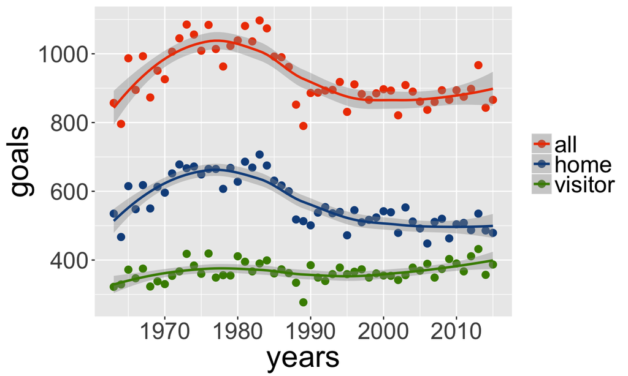